# Bellabeat Case Study with R

Nour Eldeen Anwar

2023-02-15

## About a company

Bellabeat, a high-tech manufacturer of health-focused products for women. Bellabeat is a successful small company, but they have the potential to become a larger player in the global smart device market. Urška Sršen, cofounder and Chief Creative Officer of Bellabeat, believes that analyzing smart device fitness data could help unlock new growth opportunities for the company.

### Questions for the analysis

1.What are some trends in smart device usage?

2.How could these trends apply to Bellabeat customers?

3.How could these trends help influence Bellabeat marketing strategy

### Loading packages

```r
library(tidyverse)
library(skimr)
```

```r
library(dplyr)
library(ggplot2)
library(plotly)
```

### Import and process datasets

```r
dailyActivity<-read_csv("G:/coursera/project/Fitabase Data 4.12.16-5.12.16/dailyActivity_merged.csv")%>%
  mutate(activity_days=weekdays(as.Date(ActivityDate, "%m/%d/%Y")))%>%
  drop_na()%>%
  rename_with(tolower)
dailyActivity$id<-as.character(dailyActivity$id)
skim(dailyActivity)
```

Data summary

| Name | dailyActivity |
| --- | --- |
| Number of rows | 940 |
| Number of columns | 16 |
| _______________________ |  |
| Column type frequency: |  |
| character | 3 |
| numeric | 13 |
| ________________________ |  |
| Group variables | None |

**Variable type: character**

| skim_variable | n_missing | complete_rate | min | max | empty | n_unique | whitespace |
| --- | --- | --- | --- | --- | --- | --- | --- |
| id | 0 | 1 | 10 | 10 | 0 | 33 | 0 |
| activitydate | 0 | 1 | 8 | 9 | 0 | 31 | 0 |
| activity_days | 0 | 1 | 6 | 9 | 0 | 7 | 0 |

**Variable type: numeric**

| skim_variable | n_missing | complete_rate | mean | sd | p0 | p25 | p50 | p75 | p100 | hist |
| --- | --- | --- | --- | --- | --- | --- | --- | --- | --- | --- |
| totalsteps | 0 | 1 | 7637.91 | 5087.15 | 0 | 3789.75 | 7405.50 | 10727.00 | 36019.00 | ▇▇▁▁▁ |
| totaldistance | 0 | 1 | 5.49 | 3.92 | 0 | 2.62 | 5.24 | 7.71 | 28.03 | ▇▆▁▁▁ |
| trackerdistance | 0 | 1 | 5.48 | 3.91 | 0 | 2.62 | 5.24 | 7.71 | 28.03 | ▇▆▁▁▁ |
| loggedactivitiesdistance | 0 | 1 | 0.11 | 0.62 | 0 | 0.00 | 0.00 | 0.00 | 4.94 | ▇▁▁▁▁ |
| veryactivedistance | 0 | 1 | 1.50 | 2.66 | 0 | 0.00 | 0.21 | 2.05 | 21.92 | ▇▁▁▁▁ |
| moderatelyactivedistance | 0 | 1 | 0.57 | 0.88 | 0 | 0.00 | 0.24 | 0.80 | 6.48 | ▇▁▁▁▁ |
| lightactivedistance | 0 | 1 | 3.34 | 2.04 | 0 | 1.95 | 3.36 | 4.78 | 10.71 | ▆▇▆▁▁ |
| sedentaryactivedistance | 0 | 1 | 0.00 | 0.01 | 0 | 0.00 | 0.00 | 0.00 | 0.11 | ▇▁▁▁▁ |
| veryactiveminutes | 0 | 1 | 21.16 | 32.84 | 0 | 0.00 | 4.00 | 32.00 | 210.00 | ▇▁▁▁▁ |
| fairlyactiveminutes | 0 | 1 | 13.56 | 19.99 | 0 | 0.00 | 6.00 | 19.00 | 143.00 | ▇▁▁▁▁ |
| lightlyactiveminutes | 0 | 1 | 192.81 | 109.17 | 0 | 127.00 | 199.00 | 264.00 | 518.00 | ▅▇▇▃▁ |
| sedentaryminutes | 0 | 1 | 991.21 | 301.27 | 0 | 729.75 | 1057.50 | 1229.50 | 1440.00 | ▁▁▇▅▇ |
| calories | 0 | 1 | 2303.61 | 718.17 | 0 | 1828.50 | 2134.00 | 2793.25 | 4900.00 | ▁▆▇▃▁ |

```r
glimpse(dailyActivity)
```

```
## Rows: 940
## Columns: 16
## $ id                       <chr> "1503960366", "1503960366", "1503960366", "15…
## $ activitydate             <chr> "4/12/2016", "4/13/2016", "4/14/2016", "4/15/…
## $ totalsteps               <dbl> 13162, 10735, 10460, 9762, 12669, 9705, 13019…
## $ totaldistance            <dbl> 8.50, 6.97, 6.74, 6.28, 8.16, 6.48, 8.59, 9.8…
## $ trackerdistance          <dbl> 8.50, 6.97, 6.74, 6.28, 8.16, 6.48, 8.59, 9.8…
## $ loggedactivitiesdistance <dbl> 0, 0, 0, 0, 0, 0, 0, 0, 0, 0, 0, 0, 0, 0, 0, …
## $ veryactivedistance       <dbl> 1.88, 1.57, 2.44, 2.14, 2.71, 3.19, 3.25, 3.5…
## $ moderatelyactivedistance <dbl> 0.55, 0.69, 0.40, 1.26, 0.41, 0.78, 0.64, 1.3…
## $ lightactivedistance      <dbl> 6.06, 4.71, 3.91, 2.83, 5.04, 2.51, 4.71, 5.0…
## $ sedentaryactivedistance  <dbl> 0, 0, 0, 0, 0, 0, 0, 0, 0, 0, 0, 0, 0, 0, 0, …
## $ veryactiveminutes        <dbl> 25, 21, 30, 29, 36, 38, 42, 50, 28, 19, 66, 4…
## $ fairlyactiveminutes      <dbl> 13, 19, 11, 34, 10, 20, 16, 31, 12, 8, 27, 21…
## $ lightlyactiveminutes     <dbl> 328, 217, 181, 209, 221, 164, 233, 264, 205, …
## $ sedentaryminutes         <dbl> 728, 776, 1218, 726, 773, 539, 1149, 775, 818…
## $ calories                 <dbl> 1985, 1797, 1776, 1745, 1863, 1728, 1921, 203…
## $ activity_days            <chr> "Tuesday", "Wednesday", "Thursday", "Friday",…
```

```r
max(dailyActivity$sedentaryminutes)
```

```
## [1] 1440
```

```r
dailyActivity<-filter(dailyActivity,sedentaryminutes<1436)
sum(duplicated(dailyActivity))
```

```
## [1] 0
```

```r
sum(is.na(dailyActivity))
```

```
## [1] 0
```

```r
hourlyCalories<-read_csv("G:/coursera/project/Fitabase Data 4.12.16-5.12.16/hourlyCalories_merged.csv")
hourlyCalories<-separate(hourlyCalories,ActivityHour,into = c('hourlyCaloriesDate','hourlyCaloriesTime','time' ),sep = " ")%>%
  drop_na()%>%
  rename_with(tolower)%>%
  mutate(hourlyCalories_days=weekdays(as.Date(hourlycaloriesdate , "%m/%d/%Y")))
hourlyCalories$id<-as.character(hourlyCalories$id)
skim(hourlyCalories)
```

Data summary

| Name | hourlyCalories |
| --- | --- |
| Number of rows | 22099 |
| Number of columns | 6 |
| _______________________ |  |
| Column type frequency: |  |
| character | 5 |
| numeric | 1 |
| ________________________ |  |
| Group variables | None |

**Variable type: character**

| skim_variable | n_missing | complete_rate | min | max | empty | n_unique | whitespace |
| --- | --- | --- | --- | --- | --- | --- | --- |
| id | 0 | 1 | 10 | 10 | 0 | 33 | 0 |
| hourlycaloriesdate | 0 | 1 | 8 | 9 | 0 | 31 | 0 |
| hourlycaloriestime | 0 | 1 | 7 | 8 | 0 | 12 | 0 |
| time | 0 | 1 | 2 | 2 | 0 | 2 | 0 |
| hourlyCalories_days | 0 | 1 | 6 | 9 | 0 | 7 | 0 |

**Variable type: numeric**

| skim_variable | n_missing | complete_rate | mean | sd | p0 | p25 | p50 | p75 | p100 | hist |
| --- | --- | --- | --- | --- | --- | --- | --- | --- | --- | --- |
| calories | 0 | 1 | 97.39 | 60.7 | 42 | 63 | 83 | 108 | 948 | ▇▁▁▁▁ |

```r
glimpse(hourlyCalories)
```

```
## Rows: 22,099
## Columns: 6
## $ id                  <chr> "1503960366", "1503960366", "1503960366", "1503960…
## $ hourlycaloriesdate  <chr> "4/12/2016", "4/12/2016", "4/12/2016", "4/12/2016"…
## $ hourlycaloriestime  <chr> "12:00:00", "1:00:00", "2:00:00", "3:00:00", "4:00…
## $ time                <chr> "AM", "AM", "AM", "AM", "AM", "AM", "AM", "AM", "A…
## $ calories            <dbl> 81, 61, 59, 47, 48, 48, 48, 47, 68, 141, 99, 76, 7…
## $ hourlyCalories_days <chr> "Tuesday", "Tuesday", "Tuesday", "Tuesday", "Tuesd…
```

```r
sum(duplicated(hourlyCalories))
```

```
## [1] 0
```

```r
sum(is.na(dailyActivity))
```

```
## [1] 0
```

```r
daily_sleep<-read_csv("G:/coursera/project/Fitabase Data 4.12.16-5.12.16/sleepDay_merged.csv")%>%
  drop_na()%>%
  rename_with(tolower)%>%
  distinct()%>%
  mutate(sleepDays=weekdays(as.Date(sleepday , "%m/%d/%Y")))
skim(daily_sleep)
```

Data summary

| Name | daily_sleep |
| --- | --- |
| Number of rows | 410 |
| Number of columns | 6 |
| _______________________ |  |
| Column type frequency: |  |
| character | 2 |
| numeric | 4 |
| ________________________ |  |
| Group variables | None |

**Variable type: character**

| skim_variable | n_missing | complete_rate | min | max | empty | n_unique | whitespace |
| --- | --- | --- | --- | --- | --- | --- | --- |
| sleepday | 0 | 1 | 20 | 21 | 0 | 31 | 0 |
| sleepDays | 0 | 1 | 6 | 9 | 0 | 7 | 0 |

**Variable type: numeric**

| skim_variable | n_missing | complete_rate | mean | sd | p0 | p25 | p50 | p75 | p100 | hist |
| --- | --- | --- | --- | --- | --- | --- | --- | --- | --- | --- |
| id | 0 | 1 | 4.994963e+09 | 2.060863e+09 | 1503960366 | 3.977334e+09 | 4702921684.0 | 6962181067 | 8792009665 | ▆▆▇▅▃ |
| totalsleeprecords | 0 | 1 | 1.120000e+00 | 3.500000e-01 | 1 | 1.000000e+00 | 1.0 | 1 | 3 | ▇▁▁▁▁ |
| totalminutesasleep | 0 | 1 | 4.191700e+02 | 1.186400e+02 | 58 | 3.610000e+02 | 432.5 | 490 | 796 | ▁▂▇▃▁ |
| totaltimeinbed | 0 | 1 | 4.584800e+02 | 1.274600e+02 | 61 | 4.037500e+02 | 463.0 | 526 | 961 | ▁▃▇▁▁ |

```r
daily_sleep$id<-as.character(daily_sleep$id)
daily_sleep<-separate(daily_sleep,sleepday,into = c('sleepday','sleeptime','am&pm'),sep = " ")
glimpse(daily_sleep)
```

```
## Rows: 410
## Columns: 8
## $ id                 <chr> "1503960366", "1503960366", "1503960366", "15039603…
## $ sleepday           <chr> "4/12/2016", "4/13/2016", "4/15/2016", "4/16/2016",…
## $ sleeptime          <chr> "12:00:00", "12:00:00", "12:00:00", "12:00:00", "12…
## $ `am&pm`            <chr> "AM", "AM", "AM", "AM", "AM", "AM", "AM", "AM", "AM…
## $ totalsleeprecords  <dbl> 1, 2, 1, 2, 1, 1, 1, 1, 1, 1, 1, 1, 1, 1, 1, 1, 1, …
## $ totalminutesasleep <dbl> 327, 384, 412, 340, 700, 304, 360, 325, 361, 430, 2…
## $ totaltimeinbed     <dbl> 346, 407, 442, 367, 712, 320, 377, 364, 384, 449, 3…
## $ sleepDays          <chr> "Tuesday", "Wednesday", "Friday", "Saturday", "Sund…
```

```r
sum(duplicated(daily_sleep))
```

```
## [1] 0
```

```r
sum(is.na(daily_sleep))
```

```
## [1] 0
```

```r
dailyIntensities<-read_csv("G:/coursera/project/Fitabase Data 4.12.16-5.12.16/dailyIntensities_merged.csv")%>%
  rename_with(tolower)
dailyIntensities$id<-as.character(dailyIntensities$id)
skim(dailyIntensities)
```

Data summary

| Name | dailyIntensities |
| --- | --- |
| Number of rows | 940 |
| Number of columns | 10 |
| _______________________ |  |
| Column type frequency: |  |
| character | 2 |
| numeric | 8 |
| ________________________ |  |
| Group variables | None |

**Variable type: character**

| skim_variable | n_missing | complete_rate | min | max | empty | n_unique | whitespace |
| --- | --- | --- | --- | --- | --- | --- | --- |
| id | 0 | 1 | 10 | 10 | 0 | 33 | 0 |
| activityday | 0 | 1 | 8 | 9 | 0 | 31 | 0 |

**Variable type: numeric**

| skim_variable | n_missing | complete_rate | mean | sd | p0 | p25 | p50 | p75 | p100 | hist |
| --- | --- | --- | --- | --- | --- | --- | --- | --- | --- | --- |
| sedentaryminutes | 0 | 1 | 991.21 | 301.27 | 0 | 729.75 | 1057.50 | 1229.50 | 1440.00 | ▁▁▇▅▇ |
| lightlyactiveminutes | 0 | 1 | 192.81 | 109.17 | 0 | 127.00 | 199.00 | 264.00 | 518.00 | ▅▇▇▃▁ |
| fairlyactiveminutes | 0 | 1 | 13.56 | 19.99 | 0 | 0.00 | 6.00 | 19.00 | 143.00 | ▇▁▁▁▁ |
| veryactiveminutes | 0 | 1 | 21.16 | 32.84 | 0 | 0.00 | 4.00 | 32.00 | 210.00 | ▇▁▁▁▁ |
| sedentaryactivedistance | 0 | 1 | 0.00 | 0.01 | 0 | 0.00 | 0.00 | 0.00 | 0.11 | ▇▁▁▁▁ |
| lightactivedistance | 0 | 1 | 3.34 | 2.04 | 0 | 1.95 | 3.36 | 4.78 | 10.71 | ▆▇▆▁▁ |
| moderatelyactivedistance | 0 | 1 | 0.57 | 0.88 | 0 | 0.00 | 0.24 | 0.80 | 6.48 | ▇▁▁▁▁ |
| veryactivedistance | 0 | 1 | 1.50 | 2.66 | 0 | 0.00 | 0.21 | 2.05 | 21.92 | ▇▁▁▁▁ |

```r
glimpse(dailyIntensities)
```

```
## Rows: 940
## Columns: 10
## $ id                       <chr> "1503960366", "1503960366", "1503960366", "15…
## $ activityday              <chr> "4/12/2016", "4/13/2016", "4/14/2016", "4/15/…
## $ sedentaryminutes         <dbl> 728, 776, 1218, 726, 773, 539, 1149, 775, 818…
## $ lightlyactiveminutes     <dbl> 328, 217, 181, 209, 221, 164, 233, 264, 205, …
## $ fairlyactiveminutes      <dbl> 13, 19, 11, 34, 10, 20, 16, 31, 12, 8, 27, 21…
## $ veryactiveminutes        <dbl> 25, 21, 30, 29, 36, 38, 42, 50, 28, 19, 66, 4…
## $ sedentaryactivedistance  <dbl> 0, 0, 0, 0, 0, 0, 0, 0, 0, 0, 0, 0, 0, 0, 0, …
## $ lightactivedistance      <dbl> 6.06, 4.71, 3.91, 2.83, 5.04, 2.51, 4.71, 5.0…
## $ moderatelyactivedistance <dbl> 0.55, 0.69, 0.40, 1.26, 0.41, 0.78, 0.64, 1.3…
## $ veryactivedistance       <dbl> 1.88, 1.57, 2.44, 2.14, 2.71, 3.19, 3.25, 3.5…
```

```r
sum(duplicated(dailyIntensities))
```

```
## [1] 0
```

```r
sum(is.na(dailyIntensities))
```

```
## [1] 0
```

```r
weightLogInfo<-read_csv("G:/coursera/project/Fitabase Data 4.12.16-5.12.16/weightLogInfo_merged.csv")%>%
  separate(Date,into = c('weightDate','weightTime','AM&PM' ),sep = " ")%>%
  rename_with(tolower)%>%
  mutate(weight_days=weekdays(as.Date(weightdate,"%m/%d/%Y")))%>%
  select(-fat)
weightLogInfo$id<-as.character(weightLogInfo$id)
skim(weightLogInfo)
```

Data summary

| Name | weightLogInfo |
| --- | --- |
| Number of rows | 67 |
| Number of columns | 10 |
| _______________________ |  |
| Column type frequency: |  |
| character | 5 |
| logical | 1 |
| numeric | 4 |
| ________________________ |  |
| Group variables | None |

**Variable type: character**

| skim_variable | n_missing | complete_rate | min | max | empty | n_unique | whitespace |
| --- | --- | --- | --- | --- | --- | --- | --- |
| id | 0 | 1 | 10 | 10 | 0 | 8 | 0 |
| weightdate | 0 | 1 | 8 | 9 | 0 | 31 | 0 |
| weighttime | 0 | 1 | 7 | 8 | 0 | 26 | 0 |
| am&pm | 0 | 1 | 2 | 2 | 0 | 2 | 0 |
| weight_days | 0 | 1 | 6 | 9 | 0 | 7 | 0 |

**Variable type: logical**

| skim_variable | n_missing | complete_rate | mean | count |
| --- | --- | --- | --- | --- |
| ismanualreport | 0 | 1 | 0.61 | TRU: 41, FAL: 26 |

**Variable type: numeric**

| skim_variable | n_missing | complete_rate | mean | sd | p0 | p25 | p50 | p75 | p100 | hist |
| --- | --- | --- | --- | --- | --- | --- | --- | --- | --- | --- |
| weightkg | 0 | 1 | 7.204000e+01 | 13.92 | 5.260000e+01 | 6.140000e+01 | 6.250000e+01 | 8.505000e+01 | 1.335000e+02 | ▇▃▃▁▁ |
| weightpounds | 0 | 1 | 1.588100e+02 | 30.70 | 1.159600e+02 | 1.353600e+02 | 1.377900e+02 | 1.875000e+02 | 2.943200e+02 | ▇▃▃▁▁ |
| bmi | 0 | 1 | 2.519000e+01 | 3.07 | 2.145000e+01 | 2.396000e+01 | 2.439000e+01 | 2.556000e+01 | 4.754000e+01 | ▇▁▁▁▁ |
| logid | 0 | 1 | 1.461772e+12 | 782994783.61 | 1.460444e+12 | 1.461079e+12 | 1.461802e+12 | 1.462375e+12 | 1.463098e+12 | ▇▇▆▇▇ |

```r
glimpse(weightLogInfo)
```

```
## Rows: 67
## Columns: 10
## $ id             <chr> "1503960366", "1503960366", "1927972279", "2873212765",…
## $ weightdate     <chr> "5/2/2016", "5/3/2016", "4/13/2016", "4/21/2016", "5/12…
## $ weighttime     <chr> "11:59:59", "11:59:59", "1:08:52", "11:59:59", "11:59:5…
## $ `am&pm`        <chr> "PM", "PM", "AM", "PM", "PM", "PM", "PM", "PM", "PM", "…
## $ weightkg       <dbl> 52.6, 52.6, 133.5, 56.7, 57.3, 72.4, 72.3, 69.7, 70.3, …
## $ weightpounds   <dbl> 115.9631, 115.9631, 294.3171, 125.0021, 126.3249, 159.6…
## $ bmi            <dbl> 22.65, 22.65, 47.54, 21.45, 21.69, 27.45, 27.38, 27.25,…
## $ ismanualreport <lgl> TRUE, TRUE, FALSE, TRUE, TRUE, TRUE, TRUE, TRUE, TRUE, …
## $ logid          <dbl> 1.462234e+12, 1.462320e+12, 1.460510e+12, 1.461283e+12,…
## $ weight_days    <chr> "Monday", "Tuesday", "Wednesday", "Thursday", "Thursday…
```

```r
sum(duplicated(weightLogInfo))
```

```
## [1] 0
```

```r
sum(is.na(weightLogInfo))
```

```
## [1] 0
```

### ……………….Analyze……………..

#### Count unique combinations

```r
n_distinct(dailyActivity$id)
```

```
## [1] 33
```

```r
n_distinct(weightLogInfo$id)
```

```
## [1] 8
```

```r
n_distinct(hourlyCalories$id)
```

```
## [1] 33
```

```r
n_distinct(dailyIntensities$id)
```

```
## [1] 33
```

```r
n_distinct(daily_sleep$id)
```

```
## [1] 24
```

### usage by day and user, percenatge of day covered using device

```r
hours_used <- dailyActivity %>%
  mutate(hours_used = round((veryactiveminutes + fairlyactiveminutes + lightlyactiveminutes + sedentaryminutes)/60, 2)) %>%
  mutate(hours_used_pct = round((hours_used/24), 2))%>%
  mutate(act_percent = scales::percent(hours_used_pct))

glimpse(hours_used)
```

```
## Rows: 853
## Columns: 19
## $ id                       <chr> "1503960366", "1503960366", "1503960366", "15…
## $ activitydate             <chr> "4/12/2016", "4/13/2016", "4/14/2016", "4/15/…
## $ totalsteps               <dbl> 13162, 10735, 10460, 9762, 12669, 9705, 13019…
## $ totaldistance            <dbl> 8.50, 6.97, 6.74, 6.28, 8.16, 6.48, 8.59, 9.8…
## $ trackerdistance          <dbl> 8.50, 6.97, 6.74, 6.28, 8.16, 6.48, 8.59, 9.8…
## $ loggedactivitiesdistance <dbl> 0, 0, 0, 0, 0, 0, 0, 0, 0, 0, 0, 0, 0, 0, 0, …
## $ veryactivedistance       <dbl> 1.88, 1.57, 2.44, 2.14, 2.71, 3.19, 3.25, 3.5…
## $ moderatelyactivedistance <dbl> 0.55, 0.69, 0.40, 1.26, 0.41, 0.78, 0.64, 1.3…
## $ lightactivedistance      <dbl> 6.06, 4.71, 3.91, 2.83, 5.04, 2.51, 4.71, 5.0…
## $ sedentaryactivedistance  <dbl> 0, 0, 0, 0, 0, 0, 0, 0, 0, 0, 0, 0, 0, 0, 0, …
## $ veryactiveminutes        <dbl> 25, 21, 30, 29, 36, 38, 42, 50, 28, 19, 66, 4…
## $ fairlyactiveminutes      <dbl> 13, 19, 11, 34, 10, 20, 16, 31, 12, 8, 27, 21…
## $ lightlyactiveminutes     <dbl> 328, 217, 181, 209, 221, 164, 233, 264, 205, …
## $ sedentaryminutes         <dbl> 728, 776, 1218, 726, 773, 539, 1149, 775, 818…
## $ calories                 <dbl> 1985, 1797, 1776, 1745, 1863, 1728, 1921, 203…
## $ activity_days            <chr> "Tuesday", "Wednesday", "Thursday", "Friday",…
## $ hours_used               <dbl> 18.23, 17.22, 24.00, 16.63, 17.33, 12.68, 24.…
## $ hours_used_pct           <dbl> 0.76, 0.72, 1.00, 0.69, 0.72, 0.53, 1.00, 0.7…
## $ act_percent              <chr> "76.0%", "72.0%", "100.0%", "69.0%", "72.0%",…
```

### usage hours by date

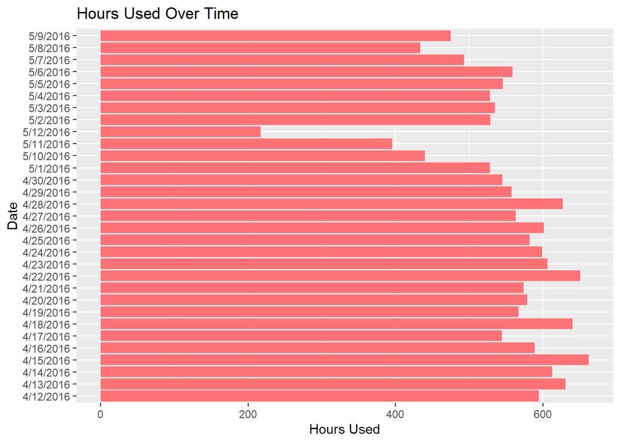

```r
ggplot(hours_used, aes(x = hours_used, y = activitydate)) +
  geom_col(fill = "#fe7275") +
  xlab("Hours Used") +
  ylab("Date") +
  ggtitle("Hours Used Over Time")
```

Looks like we can observe a usage trend here. There is a clear dip in the pattern.

### (average minutes steps per weekdays)

```r
summary_steps<-dailyActivity %>%
  group_by(activity_days) %>%
  summarise(avg_steps_minutes = round(mean(totalsteps), 2)) %>%
  arrange(-avg_steps_minutes)
summary_steps
```

```
## # A tibble: 7 × 2
##   activity_days avg_steps_minutes
##   <chr>                     <dbl>
## 1 Tuesday                   8927.
## 2 Saturday                  8899.
## 3 Monday                    8566.
## 4 Wednesday                 8311.
## 5 Thursday                  8124.
## 6 Friday                    7886.
## 7 Sunday                    7740.
```

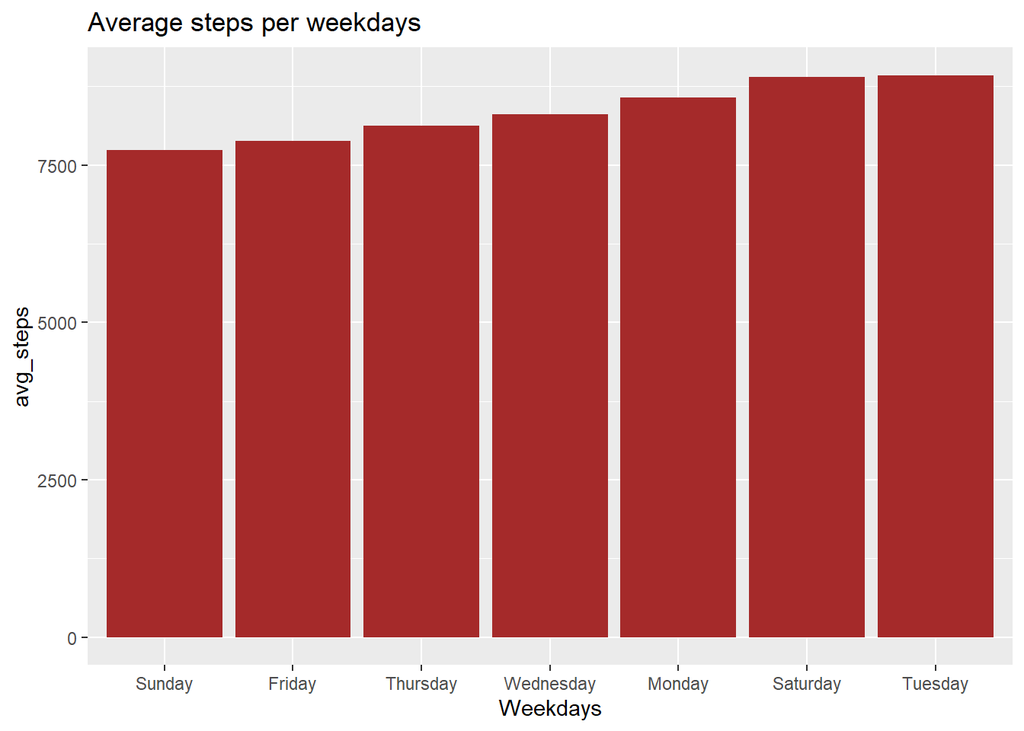

```r
ggplot(data = summary_steps)+
  geom_bar(mapping=aes(x=reorder(activity_days   , avg_steps_minutes ),y=avg_steps_minutes),stat="identity",fill="brown")+
  labs(title="Average steps per weekdays",
       x= "Weekdays",
       y= "avg_steps")
```

### Let’s check which days users sleeping more (average minutes sleep per day)

```r
summary_sleep<-daily_sleep %>%
  group_by(sleepDays) %>%
  summarise(avg_sleep_minutes = round(mean(totalminutesasleep), 2)) %>%
  arrange(-avg_sleep_minutes)
summary_sleep
```

```
## # A tibble: 7 × 2
##   sleepDays avg_sleep_minutes
##   <chr>                 <dbl>
## 1 Sunday                 453.
## 2 Wednesday              435.
## 3 Monday                 420.
## 4 Saturday               419.
## 5 Friday                 405.
## 6 Tuesday                405.
## 7 Thursday               401.
```

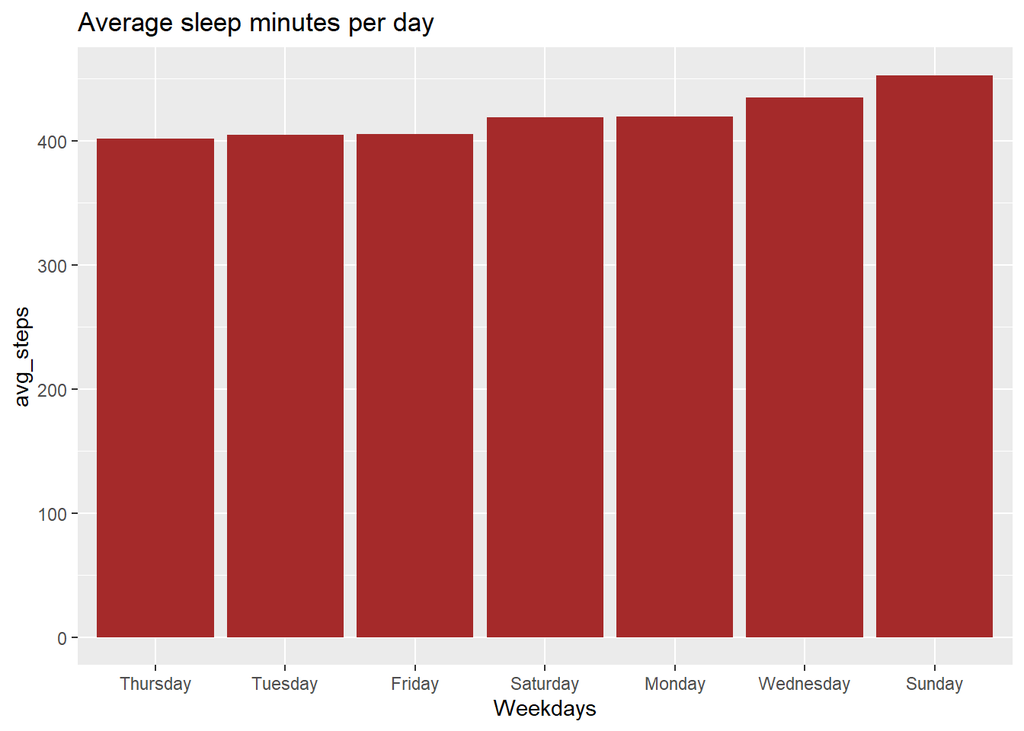

```r
ggplot(data = summary_sleep)+
  geom_bar(mapping=aes(x=reorder(sleepDays , avg_sleep_minutes ),y=avg_sleep_minutes),stat="identity",fill="brown")+
  labs(title="Average sleep minutes per day",
       x= "Weekdays",
       y= "avg_steps")
```

#### Lets group user in 4 groups according their intensity (Total Steps)

#### Insert variable activity_type depending users total steps

```r
activity_types <- dailyActivity %>%
  mutate(
    activity_type = case_when(
      dailyActivity$totalsteps < 5000 ~ "Sedentary",
      dailyActivity$totalsteps >= 5000 & dailyActivity$totalsteps < 7000 ~ "Light",
      dailyActivity$totalsteps >= 7000 & dailyActivity$totalsteps < 10000 ~ "Moderate",
      dailyActivity$totalsteps >= 10000 ~ "Vigorous"
    ))
skim(activity_types)
```

Data summary

| Name | activity_types |
| --- | --- |
| Number of rows | 853 |
| Number of columns | 17 |
| _______________________ |  |
| Column type frequency: |  |
| character | 4 |
| numeric | 13 |
| ________________________ |  |
| Group variables | None |

**Variable type: character**

| skim_variable | n_missing | complete_rate | min | max | empty | n_unique | whitespace |
| --- | --- | --- | --- | --- | --- | --- | --- |
| id | 0 | 1 | 10 | 10 | 0 | 33 | 0 |
| activitydate | 0 | 1 | 8 | 9 | 0 | 31 | 0 |
| activity_days | 0 | 1 | 6 | 9 | 0 | 7 | 0 |
| activity_type | 0 | 1 | 5 | 9 | 0 | 4 | 0 |

**Variable type: numeric**

| skim_variable | n_missing | complete_rate | mean | sd | p0 | p25 | p50 | p75 | p100 | hist |
| --- | --- | --- | --- | --- | --- | --- | --- | --- | --- | --- |
| totalsteps | 0 | 1 | 8357.66 | 4738.05 | 0 | 4933.00 | 8059.00 | 11101.00 | 36019.00 | ▇▇▂▁▁ |
| totaldistance | 0 | 1 | 6.00 | 3.72 | 0 | 3.38 | 5.60 | 7.92 | 28.03 | ▇▇▁▁▁ |
| trackerdistance | 0 | 1 | 5.99 | 3.70 | 0 | 3.38 | 5.60 | 7.89 | 28.03 | ▇▇▁▁▁ |
| loggedactivitiesdistance | 0 | 1 | 0.12 | 0.65 | 0 | 0.00 | 0.00 | 0.00 | 4.94 | ▇▁▁▁▁ |
| veryactivedistance | 0 | 1 | 1.66 | 2.75 | 0 | 0.00 | 0.43 | 2.29 | 21.92 | ▇▁▁▁▁ |
| moderatelyactivedistance | 0 | 1 | 0.63 | 0.91 | 0 | 0.00 | 0.31 | 0.87 | 6.48 | ▇▁▁▁▁ |
| lightactivedistance | 0 | 1 | 3.68 | 1.83 | 0 | 2.37 | 3.60 | 4.91 | 10.71 | ▃▇▆▁▁ |
| sedentaryactivedistance | 0 | 1 | 0.00 | 0.01 | 0 | 0.00 | 0.00 | 0.00 | 0.11 | ▇▁▁▁▁ |
| veryactiveminutes | 0 | 1 | 23.32 | 33.74 | 0 | 0.00 | 7.00 | 36.00 | 210.00 | ▇▂▁▁▁ |
| fairlyactiveminutes | 0 | 1 | 14.95 | 20.48 | 0 | 0.00 | 8.00 | 21.00 | 143.00 | ▇▁▁▁▁ |
| lightlyactiveminutes | 0 | 1 | 212.46 | 94.66 | 0 | 148.00 | 210.00 | 272.00 | 518.00 | ▂▇▇▃▁ |
| sedentaryminutes | 0 | 1 | 945.45 | 278.18 | 0 | 720.00 | 1007.00 | 1182.00 | 1431.00 | ▁▁▇▆▆ |
| calories | 0 | 1 | 2356.79 | 713.78 | 52 | 1854.00 | 2220.00 | 2832.00 | 4900.00 | ▁▆▇▃▁ |

#### The total number of each type

```r
activity_types %>%
  group_by(activity_type) %>%
  summarize(total=n())
```

```
## # A tibble: 4 × 2
##   activity_type total
##   <chr>         <int>
## 1 Light           133
## 2 Moderate        198
## 3 Sedentary       221
## 4 Vigorous        301
```

#### Create table with the % of use activity type users

```r
daily_activity_percent <- activity_types %>%
  group_by(activity_type) %>%
  summarise(total = n()) %>%
  mutate(totals = sum(total)) %>%
  group_by(activity_type) %>%
  summarise(total_percent = total / totals) %>%
  mutate(act_percent = scales::percent(total_percent))
daily_activity_percent
```

```
## # A tibble: 4 × 3
##   activity_type total_percent act_percent
##   <chr>                 <dbl> <chr>
## 1 Light                 0.156 15.6%
## 2 Moderate              0.232 23.2%
## 3 Sedentary             0.259 25.9%
## 4 Vigorous              0.353 35.3%
```

# Plot daily_activity_percent

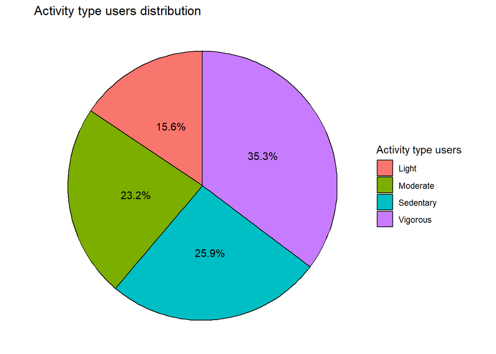

```r
ggplot(daily_activity_percent, aes(x = "", y = total_percent, fill = activity_type)) +
  geom_col(color = "black") +
  geom_text(aes(label = act_percent),
            position = position_stack(vjust = 0.5)) +
  coord_polar(theta = "y") +
  guides(fill = guide_legend(title = "Activity type users")) +
  labs(title="Activity type users distribution") +
  theme_void()
```

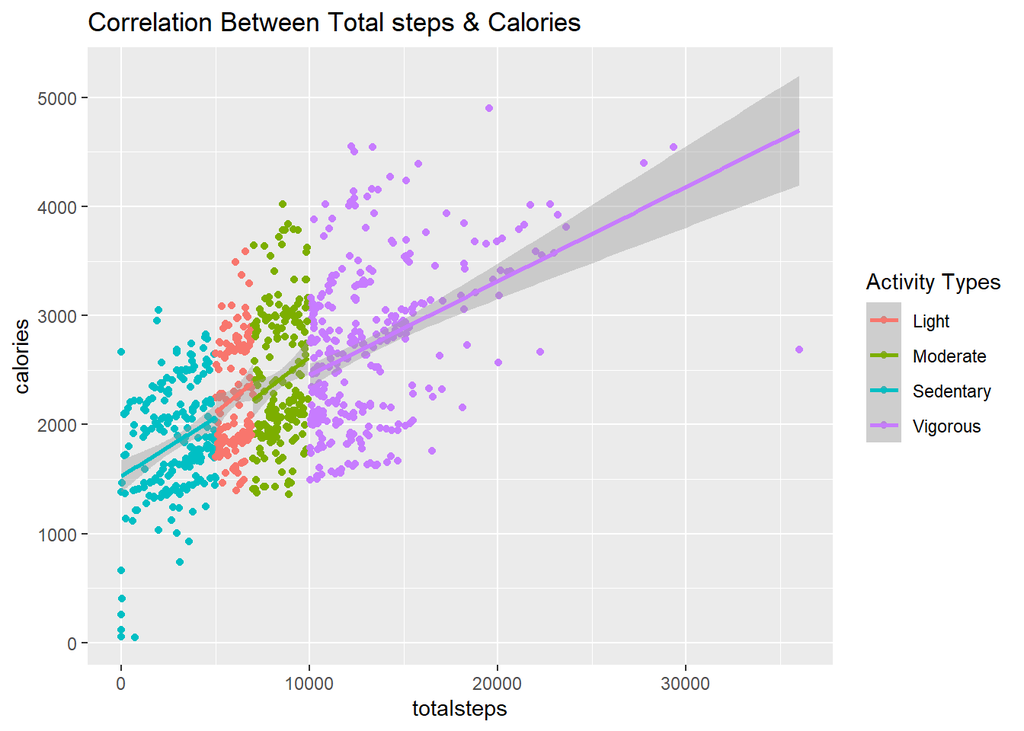

```r
ggplot(data=activity_types, aes(x=totalsteps, y=calories, color=activity_type)) +
  geom_point() + geom_smooth(formula = y ~ x, method = "gam") +
  labs(title="Correlation Between Total steps & Calories",colour="Activity Types", xlab("Total steps"))
```

#### Let’s merge between daily_Activity and Daily_sleep

```r
daily_activity_sleep<-merge(dailyActivity,daily_sleep,by="id")
skim(daily_activity_sleep)
```

Data summary

| Name | daily_activity_sleep |
| --- | --- |
| Number of rows | 11653 |
| Number of columns | 23 |
| _______________________ |  |
| Column type frequency: |  |
| character | 7 |
| numeric | 16 |
| ________________________ |  |
| Group variables | None |

**Variable type: character**

| skim_variable | n_missing | complete_rate | min | max | empty | n_unique | whitespace |
| --- | --- | --- | --- | --- | --- | --- | --- |
| id | 0 | 1 | 10 | 10 | 0 | 24 | 0 |
| activitydate | 0 | 1 | 8 | 9 | 0 | 31 | 0 |
| activity_days | 0 | 1 | 6 | 9 | 0 | 7 | 0 |
| sleepday | 0 | 1 | 8 | 9 | 0 | 31 | 0 |
| sleeptime | 0 | 1 | 8 | 8 | 0 | 1 | 0 |
| am&pm | 0 | 1 | 2 | 2 | 0 | 1 | 0 |
| sleepDays | 0 | 1 | 6 | 9 | 0 | 7 | 0 |

**Variable type: numeric**

| skim_variable | n_missing | complete_rate | mean | sd | p0 | p25 | p50 | p75 | p100 | hist |
| --- | --- | --- | --- | --- | --- | --- | --- | --- | --- | --- |
| totalsteps | 0 | 1 | 8553.97 | 4176.78 | 0 | 5206.00 | 8925.00 | 11495.00 | 22988.00 | ▅▆▇▂▁ |
| totaldistance | 0 | 1 | 6.04 | 3.04 | 0 | 3.61 | 6.37 | 8.07 | 17.95 | ▅▇▆▁▁ |
| trackerdistance | 0 | 1 | 6.03 | 3.03 | 0 | 3.61 | 6.37 | 8.06 | 17.95 | ▅▇▆▁▁ |
| loggedactivitiesdistance | 0 | 1 | 0.13 | 0.57 | 0 | 0.00 | 0.00 | 0.00 | 4.94 | ▇▁▁▁▁ |
| veryactivedistance | 0 | 1 | 1.48 | 1.94 | 0 | 0.00 | 0.65 | 2.46 | 13.40 | ▇▂▁▁▁ |
| moderatelyactivedistance | 0 | 1 | 0.77 | 1.05 | 0 | 0.00 | 0.44 | 1.06 | 6.48 | ▇▂▁▁▁ |
| lightactivedistance | 0 | 1 | 3.74 | 1.72 | 0 | 2.53 | 3.67 | 4.90 | 10.30 | ▂▇▆▁▁ |
| sedentaryactivedistance | 0 | 1 | 0.00 | 0.01 | 0 | 0.00 | 0.00 | 0.00 | 0.11 | ▇▁▁▁▁ |
| veryactiveminutes | 0 | 1 | 25.36 | 35.40 | 0 | 0.00 | 10.00 | 39.00 | 210.00 | ▇▂▁▁▁ |
| fairlyactiveminutes | 0 | 1 | 18.37 | 23.31 | 0 | 0.00 | 11.00 | 27.00 | 143.00 | ▇▂▁▁▁ |
| lightlyactiveminutes | 0 | 1 | 211.76 | 86.80 | 0 | 153.00 | 206.00 | 262.00 | 518.00 | ▂▇▇▂▁ |
| sedentaryminutes | 0 | 1 | 761.20 | 223.03 | 0 | 648.00 | 729.00 | 831.00 | 1431.00 | ▁▁▇▁▁ |
| calories | 0 | 1 | 2356.38 | 761.57 | 52 | 1797.00 | 2187.00 | 2896.00 | 4900.00 | ▁▆▇▃▁ |
| totalsleeprecords | 0 | 1 | 1.12 | 0.35 | 1 | 1.00 | 1.00 | 1.00 | 3.00 | ▇▁▁▁▁ |
| totalminutesasleep | 0 | 1 | 418.64 | 118.23 | 58 | 360.00 | 432.00 | 490.00 | 796.00 | ▁▂▇▃▁ |
| totaltimeinbed | 0 | 1 | 457.75 | 124.89 | 61 | 403.00 | 463.00 | 526.00 | 961.00 | ▁▃▇▁▁ |

```r
glimpse(daily_activity_sleep)
```

```
## Rows: 11,653
## Columns: 23
## $ id                       <chr> "1503960366", "1503960366", "1503960366", "15…
## $ activitydate             <chr> "4/20/2016", "4/20/2016", "4/20/2016", "4/20/…
## $ totalsteps               <dbl> 10544, 10544, 10544, 10544, 10544, 10544, 105…
## $ totaldistance            <dbl> 6.68, 6.68, 6.68, 6.68, 6.68, 6.68, 6.68, 6.6…
## $ trackerdistance          <dbl> 6.68, 6.68, 6.68, 6.68, 6.68, 6.68, 6.68, 6.6…
## $ loggedactivitiesdistance <dbl> 0, 0, 0, 0, 0, 0, 0, 0, 0, 0, 0, 0, 0, 0, 0, …
## $ veryactivedistance       <dbl> 1.96, 1.96, 1.96, 1.96, 1.96, 1.96, 1.96, 1.9…
## $ moderatelyactivedistance <dbl> 0.48, 0.48, 0.48, 0.48, 0.48, 0.48, 0.48, 0.4…
## $ lightactivedistance      <dbl> 4.24, 4.24, 4.24, 4.24, 4.24, 4.24, 4.24, 4.2…
## $ sedentaryactivedistance  <dbl> 0, 0, 0, 0, 0, 0, 0, 0, 0, 0, 0, 0, 0, 0, 0, …
## $ veryactiveminutes        <dbl> 28, 28, 28, 28, 28, 28, 28, 28, 28, 28, 28, 2…
## $ fairlyactiveminutes      <dbl> 12, 12, 12, 12, 12, 12, 12, 12, 12, 12, 12, 1…
## $ lightlyactiveminutes     <dbl> 205, 205, 205, 205, 205, 205, 205, 205, 205, …
## $ sedentaryminutes         <dbl> 818, 818, 818, 818, 818, 818, 818, 818, 818, …
## $ calories                 <dbl> 1786, 1786, 1786, 1786, 1786, 1786, 1786, 178…
## $ activity_days            <chr> "Wednesday", "Wednesday", "Wednesday", "Wedne…
## $ sleepday                 <chr> "4/12/2016", "4/13/2016", "4/15/2016", "4/16/…
## $ sleeptime                <chr> "12:00:00", "12:00:00", "12:00:00", "12:00:00…
## $ `am&pm`                  <chr> "AM", "AM", "AM", "AM", "AM", "AM", "AM", "AM…
## $ totalsleeprecords        <dbl> 1, 2, 1, 2, 1, 1, 1, 1, 1, 1, 1, 1, 1, 1, 1, …
## $ totalminutesasleep       <dbl> 327, 384, 412, 340, 700, 304, 360, 325, 361, …
## $ totaltimeinbed           <dbl> 346, 407, 442, 367, 712, 320, 377, 364, 384, …
## $ sleepDays                <chr> "Tuesday", "Wednesday", "Friday", "Saturday",…
```

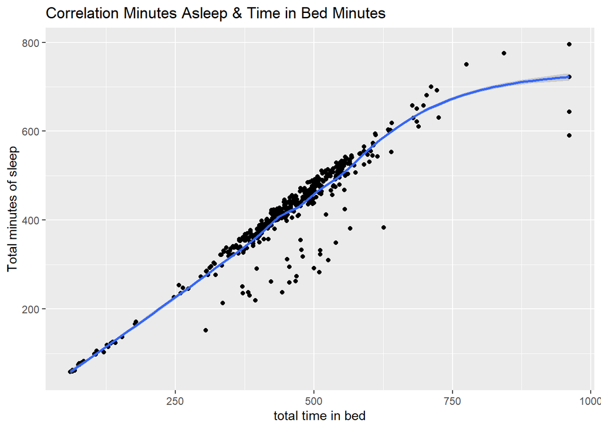

```r
ggplot(data=daily_activity_sleep, aes(x=totaltimeinbed, y=totalminutesasleep)) +
  geom_point()+ geom_smooth() + labs(title="Correlation Minutes Asleep & Time in Bed Minutes",
       x= "total time in bed",
       y= "Total minutes of sleep")
```

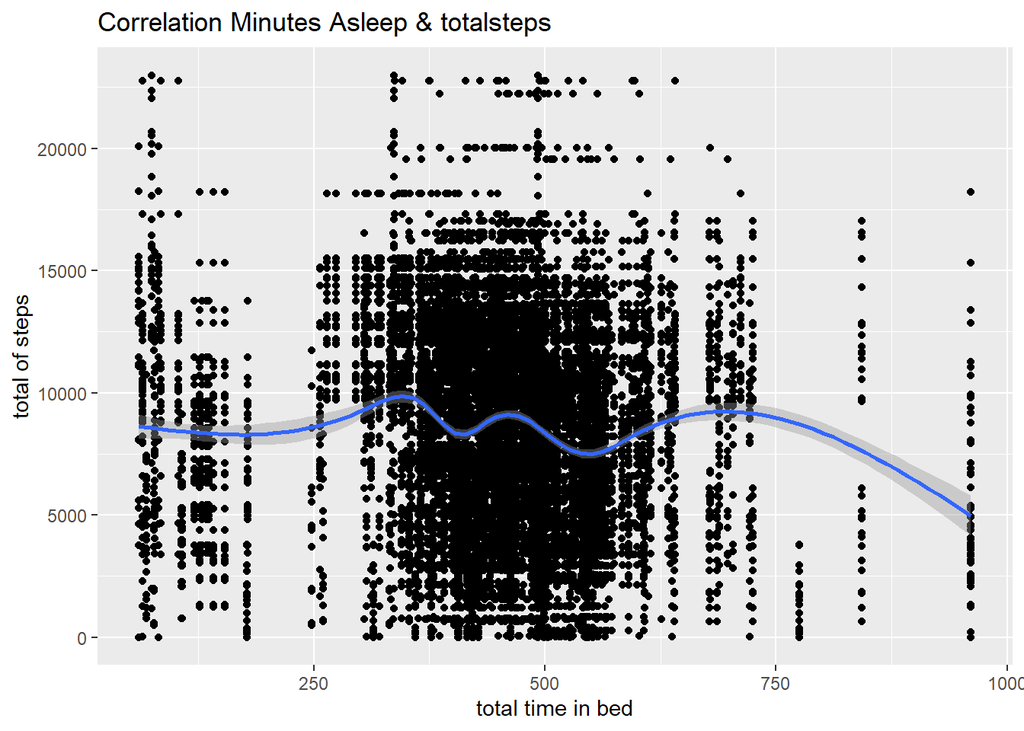

```r
ggplot(data=daily_activity_sleep, aes(x=totaltimeinbed, y=totalsteps)) +
  geom_point()+ geom_smooth() + labs(title="Correlation Minutes Asleep & totalsteps",
        x= "total time in bed",
        y= "total of steps")
```

```r
daily_activity_weight<-merge(activity_types,weightLogInfo,by="id")
n_distinct(daily_activity_weight$id)
```

```
## [1] 8
```

```r
skim(daily_activity_weight)
```

Data summary

| Name | daily_activity_weight |
| --- | --- |
| Number of rows | 2057 |
| Number of columns | 26 |
| _______________________ |  |
| Column type frequency: |  |
| character | 8 |
| logical | 1 |
| numeric | 17 |
| ________________________ |  |
| Group variables | None |

**Variable type: character**

| skim_variable | n_missing | complete_rate | min | max | empty | n_unique | whitespace |
| --- | --- | --- | --- | --- | --- | --- | --- |
| id | 0 | 1 | 10 | 10 | 0 | 8 | 0 |
| activitydate | 0 | 1 | 8 | 9 | 0 | 31 | 0 |
| activity_days | 0 | 1 | 6 | 9 | 0 | 7 | 0 |
| activity_type | 0 | 1 | 5 | 9 | 0 | 4 | 0 |
| weightdate | 0 | 1 | 8 | 9 | 0 | 31 | 0 |
| weighttime | 0 | 1 | 7 | 8 | 0 | 26 | 0 |
| am&pm | 0 | 1 | 2 | 2 | 0 | 2 | 0 |
| weight_days | 0 | 1 | 6 | 9 | 0 | 7 | 0 |

**Variable type: logical**

| skim_variable | n_missing | complete_rate | mean | count |
| --- | --- | --- | --- | --- |
| ismanualreport | 0 | 1 | 0.62 | TRU: 1267, FAL: 790 |

**Variable type: numeric**

| skim_variable | n_missing | complete_rate | mean | sd | p0 | p25 | p50 | p75 | p100 | hist |
| --- | --- | --- | --- | --- | --- | --- | --- | --- | --- | --- |
| totalsteps | 0 | 1 | 1.174844e+04 | 5617.32 | 0.000000e+00 | 8.06400e+03 | 1.076200e+04 | 1.392800e+04 | 2.932600e+04 | ▃▇▅▂▁ |
| totaldistance | 0 | 1 | 8.770000e+00 | 5.36 | 0.000000e+00 | 5.54000e+00 | 7.430000e+00 | 9.550000e+00 | 2.672000e+01 | ▃▇▁▂▁ |
| trackerdistance | 0 | 1 | 8.740000e+00 | 5.36 | 0.000000e+00 | 5.54000e+00 | 7.430000e+00 | 9.250000e+00 | 2.672000e+01 | ▃▇▁▂▁ |
| loggedactivitiesdistance | 0 | 1 | 1.500000e-01 | 0.69 | 0.000000e+00 | 0.00000e+00 | 0.000000e+00 | 0.000000e+00 | 4.080000e+00 | ▇▁▁▁▁ |
| veryactivedistance | 0 | 1 | 3.330000e+00 | 4.43 | 0.000000e+00 | 3.30000e-01 | 1.740000e+00 | 3.900000e+00 | 2.166000e+01 | ▇▁▁▁▁ |
| moderatelyactivedistance | 0 | 1 | 6.700000e-01 | 0.69 | 0.000000e+00 | 1.00000e-01 | 4.200000e-01 | 1.080000e+00 | 2.390000e+00 | ▇▂▁▁▂ |
| lightactivedistance | 0 | 1 | 4.740000e+00 | 1.76 | 0.000000e+00 | 3.65000e+00 | 4.690000e+00 | 5.890000e+00 | 1.071000e+01 | ▁▆▇▂▁ |
| sedentaryactivedistance | 0 | 1 | 1.000000e-02 | 0.02 | 0.000000e+00 | 0.00000e+00 | 0.000000e+00 | 0.000000e+00 | 1.100000e-01 | ▇▁▁▁▁ |
| veryactiveminutes | 0 | 1 | 3.798000e+01 | 34.98 | 0.000000e+00 | 8.00000e+00 | 3.000000e+01 | 6.200000e+01 | 2.100000e+02 | ▇▃▂▁▁ |
| fairlyactiveminutes | 0 | 1 | 1.458000e+01 | 12.95 | 0.000000e+00 | 4.00000e+00 | 1.200000e+01 | 2.200000e+01 | 7.400000e+01 | ▇▃▂▁▁ |
| lightlyactiveminutes | 0 | 1 | 2.430500e+02 | 69.50 | 0.000000e+00 | 2.12000e+02 | 2.360000e+02 | 2.880000e+02 | 4.480000e+02 | ▁▂▇▅▁ |
| sedentaryminutes | 0 | 1 | 8.827400e+02 | 252.16 | 0.000000e+00 | 6.80000e+02 | 8.370000e+02 | 1.122000e+03 | 1.430000e+03 | ▁▁▇▆▃ |
| calories | 0 | 1 | 2.525220e+03 | 822.91 | 2.570000e+02 | 1.99400e+03 | 2.174000e+03 | 3.060000e+03 | 4.552000e+03 | ▁▃▇▂▂ |
| weightkg | 0 | 1 | 7.164000e+01 | 12.96 | 5.260000e+01 | 6.14000e+01 | 6.250000e+01 | 8.500000e+01 | 1.335000e+02 | ▇▃▃▁▁ |
| weightpounds | 0 | 1 | 1.579400e+02 | 28.57 | 1.159600e+02 | 1.35360e+02 | 1.377900e+02 | 1.873900e+02 | 2.943200e+02 | ▇▃▃▁▁ |
| bmi | 0 | 1 | 2.504000e+01 | 2.48 | 2.145000e+01 | 2.39600e+01 | 2.439000e+01 | 2.556000e+01 | 4.754000e+01 | ▇▁▁▁▁ |
| logid | 0 | 1 | 1.461780e+12 | 773317473.61 | 1.460444e+12 | 1.46111e+12 | 1.461802e+12 | 1.462406e+12 | 1.463098e+12 | ▇▇▆▇▇ |

```r
glimpse(daily_activity_weight)
```

```
## Rows: 2,057
## Columns: 26
## $ id                       <chr> "1503960366", "1503960366", "1503960366", "15…
## $ activitydate             <chr> "5/6/2016", "5/6/2016", "4/12/2016", "4/12/20…
## $ totalsteps               <dbl> 12159, 12159, 13162, 13162, 11181, 11181, 104…
## $ totaldistance            <dbl> 8.03, 8.03, 8.50, 8.50, 7.15, 7.15, 6.74, 6.7…
## $ trackerdistance          <dbl> 8.03, 8.03, 8.50, 8.50, 7.15, 7.15, 6.74, 6.7…
## $ loggedactivitiesdistance <dbl> 0, 0, 0, 0, 0, 0, 0, 0, 0, 0, 0, 0, 0, 0, 0, …
## $ veryactivedistance       <dbl> 1.97, 1.97, 1.88, 1.88, 1.06, 1.06, 2.44, 2.4…
## $ moderatelyactivedistance <dbl> 0.25, 0.25, 0.55, 0.55, 0.50, 0.50, 0.40, 0.4…
## $ lightactivedistance      <dbl> 5.81, 5.81, 6.06, 6.06, 5.58, 5.58, 3.91, 3.9…
## $ sedentaryactivedistance  <dbl> 0, 0, 0, 0, 0, 0, 0, 0, 0, 0, 0, 0, 0, 0, 0, …
## $ veryactiveminutes        <dbl> 24, 24, 25, 25, 16, 16, 30, 30, 45, 45, 66, 6…
## $ fairlyactiveminutes      <dbl> 6, 6, 13, 13, 12, 12, 11, 11, 24, 24, 27, 27,…
## $ lightlyactiveminutes     <dbl> 289, 289, 328, 328, 243, 243, 181, 181, 250, …
## $ sedentaryminutes         <dbl> 754, 754, 728, 728, 815, 815, 1218, 1218, 857…
## $ calories                 <dbl> 1896, 1896, 1985, 1985, 1837, 1837, 1776, 177…
## $ activity_days            <chr> "Friday", "Friday", "Tuesday", "Tuesday", "Fr…
## $ activity_type            <chr> "Vigorous", "Vigorous", "Vigorous", "Vigorous…
## $ weightdate               <chr> "5/2/2016", "5/3/2016", "5/2/2016", "5/3/2016…
## $ weighttime               <chr> "11:59:59", "11:59:59", "11:59:59", "11:59:59…
## $ `am&pm`                  <chr> "PM", "PM", "PM", "PM", "PM", "PM", "PM", "PM…
## $ weightkg                 <dbl> 52.6, 52.6, 52.6, 52.6, 52.6, 52.6, 52.6, 52.…
## $ weightpounds             <dbl> 115.9631, 115.9631, 115.9631, 115.9631, 115.9…
## $ bmi                      <dbl> 22.65, 22.65, 22.65, 22.65, 22.65, 22.65, 22.…
## $ ismanualreport           <lgl> TRUE, TRUE, TRUE, TRUE, TRUE, TRUE, TRUE, TRU…
## $ logid                    <dbl> 1.462234e+12, 1.462320e+12, 1.462234e+12, 1.4…
## $ weight_days              <chr> "Monday", "Tuesday", "Monday", "Tuesday", "Mo…
```

```r
time<-hourlyCalories %>%
  group_by(time) %>%
  summarise(total_calories =sum(calories)) %>%
  arrange(-total_calories)
time
```

```
## # A tibble: 2 × 2
##   time  total_calories
##   <chr>          <dbl>
## 1 PM           1183896
## 2 AM            968254
```

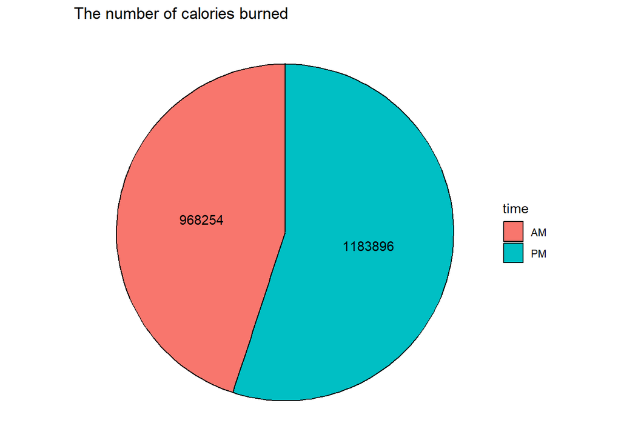

```r
ggplot(data=time, aes(x = "", y = total_calories, fill = time)) +
  geom_col(color = "black") +
  geom_text(aes(label = total_calories),
            position = position_stack(vjust = 0.5)) +
  coord_polar(theta = "y") +
  labs(title="The number of calories burned") +
  theme_void()
```

### Recommendations

1.Based on this data Find ways to use the Bellabeat app to encourage users to decrease their sedentary minutes , perhaps by vibrating, send notifications etc.

2.Users that consistently record step totals, or calories burned could earn achievements or trophies through the app.

3 Users can be notified on Sunday and increase prizes to encourage them to be more active